# Predictive Capabilities of LASSO Regression

Author

Kayla Hayes, HJ Kim, Kristy Tarano, Andrew Melara-Suazo

Published

July 29, 2024

Presentation

## Introduction & Literature Review

Genetics continue to shape human existence, even after thousands of years. With the use of advancing technology and increasingly available genotype and phenotype data, biomedical scientists are making significant strides in the understanding of genetic predisposition later leading to the development of diseases or disorders (Claussnitzer et al. 2020). The time commitment required for decision making in the diagnosis of cases involving genome variation is daunting due to the complex nature of the clinical effects, and as a consequence the medical industry now relies more heavily on technology to assist in these diagnoses. In one article, a collaboration between China’s BGI Genomics and Fuyang People’s Hospital demonstrated the abilities of a chip designed to detect the many variations in genes. The end goal of chips like these is to lower overall time required and cost of diagnoses, especially those relating to genetic mutations (Y. Liu et al. 2023).

Even with technology, however, there are still many inefficiencies to address. One of these inefficiencies exists in the overuse of Computerized Clinical Decision Support Systems (CCDSS) to order lab tests such as in the case of Fondazione Policlinico Universitario Agostino Gemelli, a large university hospital located in Rome. This study found that labs are required to make critical judgments in 70 to 80% of cases, causing it to become common practice for medical professionals to order many tests that are unnecessary (Tamburrano et al. 2020). Studies like that of the CCDSS in the Italian university hospital put the research community at a crossroads because these computerized diagnosis systems are intended to be an assistive tool for medical professionals to utilize. Crossroads aside, researchers continue to break boundaries in the diagnoses of genetic disorders with the increasing application of machine learning to create predictive models. Because so many diseases and disorders are linked to varying degrees of gene expression and mutation, proper organization of these categories through classification methods is needed to gain insight (Raza et al. 2022).

The Mean Squared Error is commonly used to measure the accuracy of any given regression model and when utilizing LASSO regression, any coefficients with very high values can be reduced all the way down to zero by the introduction of a bias (Hodson 2022). LASSO adds a penalization parameter, also referred to as the L1 Penalty, which determines how much shrinkage will occur to the model’s coefficients (Freijeiro-González, Febrero-Bande, and González-Manteiga 2022). The L1 Penalty is determined by λ multiplied against the absolute value of the slope of a fitted line where the sum of squared residuals is added to the penalty to increase the bias and offset the variance of the model which proves to be useful for developing predictive models (Greenwood et al. 2020). The use of LASSO regression to perform feature selection produces a higher level of accuracy and precision when coupled with a machine learning model to predict gene patterns relating to cancer diagnosis (GUHA 2024).

In this analysis, demographic factors and health indicators are used to predict various disorder sub-classes. Moreover, the optimizing capabilities of LASSO regression are combined with the predictive capabilities of multinomial logistic regression to train a model that can determine a correct disorder and subclass outcome. Several participant identifying fields are omitted from the analysis and the primary goal is to solely use key demographic and health information to make all determinations. This model ideally assists in better understanding what factors play a role in the diagnoses of specific disorders as well as how machine learning can be used as a tool to increase the efficiency of medical diagnoses.

## Methods

LASSO regression was conducted as a means to tune our model and to minimize variables with low impact to our outcome variable. To develop a baseline for performing LASSO Regression, we began with a multinomial logistic regression model. The multinomial logistic regression model is formulated as shown below:

$$logit(Pi)=ln(\frac{Pi}{Preference}) = \beta_0 + \beta_1 x_1 + \beta_2 x_2 + \cdots + \beta_k x_k$$

In this model, the logarithm of the odds is set equal to the intercept value plus the coefficients of X. The assumption of this function is that p(X) should always be between 0 and 1. This logistic regression formula consequentially forms into an S shaped curve to fit those parameters.

$$\hat{\beta} = \arg\min_{\beta} \left( \frac{1}{2n} \sum_{i=1}^n (y_i - X_i \beta)^2 + \lambda \sum_{j=1}^p |\beta_j| \right)$$

LASSO regression is an optimizing feature selection technique used to assist with common regression problems such as the aforementioned reduction of overfitting through regularization. The purpose of using a regularization technique such as LASSO regression is to introduce a penalization parameter known as L1. L1 is determined by multiplying Lambda with the sums of the absolute values of the estimated parameters, demonstrated by the portion of the formula shown here:

$$\lambda \sum_{j=1}^p |\beta_j|$$

K-Fold Cross Validation involves splitting the data into “k” number of folds. The first formula shown here computes log loss for each fold which then is summed up to get an overall error measure for each lambda. K-Fold Cross Validation was used to determine the best lambda value, that results in the minimum mean cross-validated error (log loss) (Yates 2023).

$$\text{Log Loss} = -\frac{1}{n} \sum_{i=1}^n \left[ y_i \log(\hat{y}_i) + (1 - y_i) \log(1 - \hat{y}_i) \right]$$

$$\text{K-Fold Cross Validation} = \frac{1}{K} \sum_{k=1}^K \text{Err}_k$$

## Analysis and Results

### Data and Visualization

The data employed throughout this study is sourced from a genomics dataset which recorded various demographic and health indicators describing a set of patients’ respective disorders and disorder subclasses. The dataset contains 45 variables that are a mix between categorical and continuous types which ultimately describe the genetic disorders. This data in its original form is split into individual training and testing datasets, but for this study only the training dataset is utilized. The training data itself is split into its own training and testing set for proof of concept.

#### Variables in Original Dataset

```r
# Packages Used

library(tidyverse)
library(knitr)
library(ggthemes)
library(ggrepel)
library(dslabs)
library(dplyr)
library(DT)
library(glmnet)
library(fastDummies)
library(nnet)
library(plyr)
library(readxl)
#install.packages("naniar")
library(naniar)
#install.packages("VIM")
library(data.table)
#install.packages("mltools")
library(mltools)
library(ggplot2)
library(reshape2)
library(tidyr)
library(purrr)

# Load Data

Variables <- read.csv("Variables - Sheet1.csv", header = TRUE)

# Display the Variables table

datatable(Variables)
```

|  | Item | Type | Description |
| --- | --- | --- | --- |
| 1 | Patient ID | String | ID |
| 2 | Patient Age | Integer | Age |
| 3 | Genes in mother's side | Boolean | Cause |
| 4 | Inherited from father | Boolean | Cause |
| 5 | Maternal gene | Boolean | Cause |
| 6 | Paternal gene | Boolean | Cause |
| 7 | Blood cell count (mcL) | Decimal | Count |
| 8 | Patient First Name | String | Name |
| 9 | Family Name | String | Name |
| 10 | Father's name | String | Name |

[output cut: 35 more lines]

#### Target Data from Original Dataset

```r
Target <- read.csv("Target - Sheet1.csv", header = TRUE)

# Display the Target Data table

datatable(Target)
```

|  | Subclass.Disease | Mitochondrial.genetic.inheritance.disorders | Multifactorial.genetic.inheritance.disorders | Single.gene.inheritance.diseases | X.Vacant. | Total |
| --- | --- | --- | --- | --- | --- | --- |
| 1 | Alzheimer's |  | 133 |  | 19 | 152 |
| 2 | Cancer |  | 91 |  | 6 | 97 |
| 3 | Cystic fibrosis |  |  | 3145 | 303 | 3448 |
| 4 | Diabetes |  | 1653 |  | 164 | 1817 |
| 5 | Hemochromatosis |  |  | 1228 | 127 | 1355 |
| 6 | Leber's hereditary optic neuropathy | 587 |  |  | 61 | 648 |
| 7 | Leigh syndrome | 4683 |  |  | 477 | 5160 |
| 8 | Mitochondrial myopathy | 3971 |  |  | 434 | 4405 |
| 9 | Tay-Sachs |  |  | 2556 | 277 | 2833 |
| 10 | Vacant | 961 | 194 | 735 | 278 | 2168 |

[output cut: 1 more lines]

#### Data Cleaning

During pre-processing, non-informative patient identification variables were cleaned from the dataset to remove insignificant predictive variables relating to the outcome. A multinomial logistic regression model was then developed to predict a genetic disorder outcome for patients based solely on their recorded information.

## Statistical Analysis

```r
# loading packages
library(tidyverse)
library(knitr)
library(ggthemes)
library(ggrepel)
library(dslabs)
library(glmnet)
library(fastDummies)
library(nnet)

#Loading data
genetic_data <- read_csv('train_genetics.csv')

#Removing NA from data
clean_gene_data <- na.omit(genetic_data)

#Creating dummy columns
clean_gene_data <- dummy_cols(clean_gene_data, select_columns = c("Respiratory Rate (breaths/min)","Gender" ,"Heart Rate (rates/min", "H/O radiation exposure (x-ray)", "Birth asphyxia", "H/O substance abuse", "Birth defects", "H/O substance abuse", "Blood test result", "Disorder Subclass"), remove_first_dummy = TRUE)

# for consistency
set.seed(234)

# Get row indices for the training set and setting split
train_indices <- sample(seq_len(nrow(clean_gene_data)), size = 0.8 * nrow(clean_gene_data))

# Split the data into 80:20
train_data <- clean_gene_data[train_indices, ] # should be about 80% of the original data
test_data <- clean_gene_data[-train_indices, ] # should be about 20% of the original data


#Defining the response variable
y <- as.factor(train_data$`Genetic Disorder`)


#Defining the matrix of predictor variables for the model
x <- data.matrix(train_data[,c ("Genes in mother's side",'Maternal gene','Paternal gene' ,'Inherited from father', 'Blood cell count (mcL)', 'Respiratory Rate (breaths/min)_Tachypnea', 'Heart Rate (rates/min_Tachycardia','Gender_Female', 'Gender_Male','Birth asphyxia_No record', 'Birth asphyxia_Not available','Birth asphyxia_Yes','Folic acid details (peri-conceptional)', 'H/O serious maternal illness', 'H/O radiation exposure (x-ray)_No', 'H/O radiation exposure (x-ray)_Not applicable', 'H/O radiation exposure (x-ray)_Yes', 'H/O substance abuse_No', 'H/O substance abuse_Not applicable', 'H/O substance abuse_Yes', 'Assisted conception IVF/ART', 'History of a0malies in previous pregnancies', 'Birth defects_Singular', 'Blood test result_inconclusive', 'Blood test result_normal', 'Blood test result_slightly abnormal','White Blood cell count (thousand per microliter)', 'Symptom 1', 'Symptom 2','Symptom 3','Symptom 4', 'Symptom 5', 'Test 1', 'Test 2','Test 3','Test 4', 'Test 5', 'Disorder Subclass_Cancer', 'Disorder Subclass_Cystic fibrosis', 'Disorder Subclass_Diabetes', 'Disorder Subclass_Hemochromatosis', "Disorder Subclass_Leber's hereditary optic neuropathy", 'Disorder Subclass_Leigh syndrome', 'Disorder Subclass_Mitochondrial myopathy', 'Disorder Subclass_Tay-Sachs')])


#Looking for optimal lamda value using k-fold cross validation
cross_val_model <- cv.glmnet(x, y, family = "multinomial", alpha= 1)

#Looking for the best lambda value
min_lambda <- cross_val_model$lambda.min

#Value of Lambda
min_lambda
```

```
[1] 0.0002451145
```

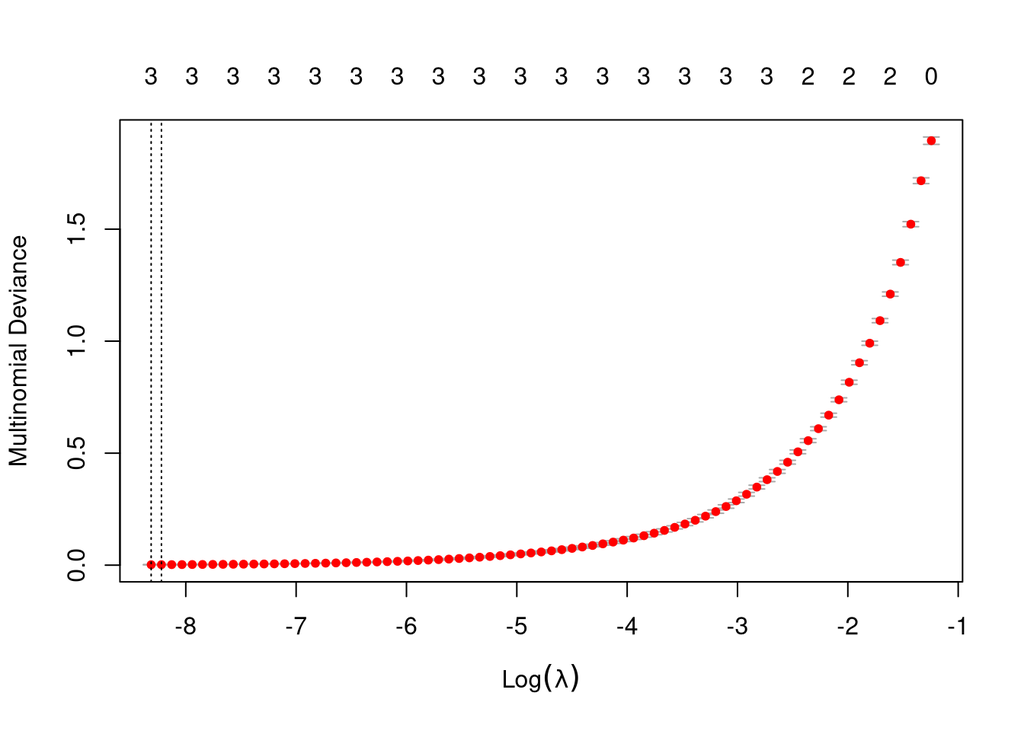

```r
#Graph of test MSE error
plot(cross_val_model)
```

```r
#Creating our LASSO regression model
gene_model <- glmnet(x, y, family = "multinomial", alpha = 1, lambda = min_lambda)

#Coefficients of the model
coef(gene_model)
```

```
$`Mitochondrial genetic inheritance disorders`
46 x 1 sparse Matrix of class "dgCMatrix"
                                                             s0
                                                      -0.028792
Genes in mother's side                                 .
Maternal gene                                          .
Paternal gene                                          .
Inherited from father                                  .
Blood cell count (mcL)                                 .
Respiratory Rate (breaths/min)_Tachypnea               .
Heart Rate (rates/min_Tachycardia                      .
Gender_Female                                          .
Gender_Male                                            .
Birth asphyxia_No record                               .
Birth asphyxia_Not available                           .
Birth asphyxia_Yes                                     .
Folic acid details (peri-conceptional)                 .
H/O serious maternal illness                           .
H/O radiation exposure (x-ray)_No                      .
H/O radiation exposure (x-ray)_Not applicable          .
H/O radiation exposure (x-ray)_Yes                     .
H/O substance abuse_No                                 .
H/O substance abuse_Not applicable                     .
H/O substance abuse_Yes                                .
Assisted conception IVF/ART                            .
History of a0malies in previous pregnancies            .
Birth defects_Singular                                 .
Blood test result_inconclusive                         .
Blood test result_normal                               .
Blood test result_slightly abnormal                    .
White Blood cell count (thousand per microliter)       .
Symptom 1                                              .
Symptom 2                                              .
Symptom 3                                              .
Symptom 4                                              .
Symptom 5                                              .
Test 1                                                 .
Test 2                                                 .
Test 3                                                 .
Test 4                                                 .
```

[output cut: 94 more lines]

```
Symptom 4                                              .
Symptom 5                                              .
Test 1                                                 .
Test 2                                                 .
Test 3                                                 .
Test 4                                                 .
Test 5                                                 .
Disorder Subclass_Cancer                               .
Disorder Subclass_Cystic fibrosis                     10.62654612
Disorder Subclass_Diabetes                             .
Disorder Subclass_Hemochromatosis                      8.30586094
Disorder Subclass_Leber's hereditary optic neuropathy  .
Disorder Subclass_Leigh syndrome                       .
Disorder Subclass_Mitochondrial myopathy               .
Disorder Subclass_Tay-Sachs                            9.02598863
```

```r
print(gene_model)
```

```
Call:  glmnet(x = x, y = y, family = "multinomial", alpha = 1, lambda = min_lambda)

  Df %Dev    Lambda
1 16 99.9 0.0002451
```

```r
#Creating matrix of predictor variables from test data
x_test <- data.matrix(test_data[,c ("Genes in mother's side",'Maternal gene','Paternal gene' ,'Inherited from father', 'Blood cell count (mcL)', 'Respiratory Rate (breaths/min)_Tachypnea', 'Heart Rate (rates/min_Tachycardia','Gender_Female', 'Gender_Male','Birth asphyxia_No record', 'Birth asphyxia_Not available','Birth asphyxia_Yes','Folic acid details (peri-conceptional)', 'H/O serious maternal illness', 'H/O radiation exposure (x-ray)_No', 'H/O radiation exposure (x-ray)_Not applicable', 'H/O radiation exposure (x-ray)_Yes', 'H/O substance abuse_No', 'H/O substance abuse_Not applicable', 'H/O substance abuse_Yes', 'Assisted conception IVF/ART', 'History of a0malies in previous pregnancies', 'Birth defects_Singular', 'Blood test result_inconclusive', 'Blood test result_normal', 'Blood test result_slightly abnormal','White Blood cell count (thousand per microliter)', 'Symptom 1', 'Symptom 2','Symptom 3','Symptom 4', 'Symptom 5', 'Test 1', 'Test 2','Test 3','Test 4', 'Test 5', 'Disorder Subclass_Cancer', 'Disorder Subclass_Cystic fibrosis', 'Disorder Subclass_Diabetes', 'Disorder Subclass_Hemochromatosis', "Disorder Subclass_Leber's hereditary optic neuropathy", 'Disorder Subclass_Leigh syndrome', 'Disorder Subclass_Mitochondrial myopathy', 'Disorder Subclass_Tay-Sachs')])

#Defining response variable from test data
y_test <- as.factor(test_data$`Genetic Disorder`)



#CONFUSION MATRIX BELOW

#Creating prediction classes for the model
pred_prob <- predict(gene_model, newx = x_test, s = min_lambda, type = "class")

#Creating the prediction probability threshold for the model
pred_class <- ifelse(pred_prob > 0.05, 1, 0)

#Creating the confusion matrix
confusion_matrix <- table(Predicted = pred_class, Actual = y_test)

print(confusion_matrix)
```

```
         Actual
Predicted Mitochondrial genetic inheritance disorders
        1                                         663
         Actual
Predicted Multifactorial genetic inheritance disorders
        1                                          135
         Actual
Predicted Single-gene inheritance diseases
        1                              544
```

```r
#Calculates the overall true positive/negatives over the sum of all predictions
accuracy <- sum(diag(confusion_matrix)) / sum(confusion_matrix)

# Print the accuracy decimal
print(paste("Accuracy:", round(accuracy, 4)))
```

```
[1] "Accuracy: 0.494"
```

```r
#Decimal proportion of true positives over true and false positive predictions
precision <- diag(confusion_matrix) / rowSums(confusion_matrix)

#Decimal proportion of true positives over true and false negative predictions
recall <- diag(confusion_matrix) / colSums(confusion_matrix)

#F1 Score measures accuracy and considers precision and recall and also accounts for false + and -
f1_score <- 2 * (precision * recall) / (precision + recall)


f1_score
```

[output not shown]

## References

Abdulhafedh, Azad. 2022. “Modeling Vehicle Crash Frequency When Multicollinearity Exists in Vehicle Crash Data: Ridge Regression Versus Ordinary Least Squares Linear Regression.” *Open Access Library Journal* 9 (6): 1–17.

Claussnitzer, Melina, Judy H Cho, Rory Collins, Nancy J Cox, Emmanouil T Dermitzakis, Matthew E Hurles, Sekar Kathiresan, et al. 2020. “A Brief History of Human Disease Genetics.” *Nature* 577 (7789): 179–89.

Freijeiro-González, Laura, Manuel Febrero-Bande, and Wenceslao González-Manteiga. 2022. “A Critical Review of LASSO and Its Derivatives for Variable Selection Under Dependence Among Covariates.” *International Statistical Review* 90 (1): 118–45.

Greenwood, Christopher J, George J Youssef, Primrose Letcher, Jacqui A Macdonald, Lauryn J Hagg, Ann Sanson, Jenn Mcintosh, et al. 2020. “A Comparison of Penalised Regression Methods for Informing the Selection of Predictive Markers.” *PloS One* 15 (11): e0242730.

GUHA, SOUVIK. 2024. “Feature Selection Using Lasso Regression Enhances Deep Learning Model Performance for Diagnosis of Lung Cancer from Transcriptomic Data.” *bioRxiv*, 2024–05.

Hodson, Timothy O. 2022. “Root Mean Square Error (RMSE) or Mean Absolute Error (MAE): When to Use Them or Not.” *Geoscientific Model Development Discussions* 2022: 1–10.

Liu, Shuai, Mengye Lu, Hanshuang Li, and Yongchun Zuo. 2019. “Prediction of Gene Expression Patterns with Generalized Linear Regression Model.” *Frontiers in Genetics* 10: 120.

Liu, Yanqiu, Liangwei Mao, Hui Huang, Wei Li, Jianfen Man, Wenqian Zhang, Lina Wang, et al. 2023. “Clinical Diagnosis of Genetic Disorders at Both Single-Nucleotide and Chromosomal Levels Based on BGISEQ-500 Platform.” *Human Genome Variation* 10 (1): 15.

Meysami, Mohammad, Vijay Kumar, McKayah Pugh, Samuel Thomas Lowery, Shantanu Sur, Sumona Mondal, and James M Greene. 2023. “Utilizing Logistic Regression to Compare Risk Factors in Disease Modeling with Imbalanced Data: A Case Study in Vitamin d and Cancer Incidence.” *Frontiers in Oncology* 13: 1227842.

Ranstam, Jonas, and Jonathan A Cook. 2018. “LASSO Regression.” *Journal of British Surgery* 105 (10): 1348–48.

Raza, Ali, Furqan Rustam, Hafeez Ur Rehman Siddiqui, Isabel de la Torre Diez, Begoña Garcia-Zapirain, Ernesto Lee, and Imran Ashraf. 2022. “Predicting Genetic Disorder and Types of Disorder Using Chain Classifier Approach.” *Genes* 14 (1): 71.

Rusyana, A, KA Notodiputro, and B Sartono. 2021. “The Lasso Binary Logistic Regression Method for Selecting Variables That Affect the Recovery of Covid-19 Patients in China.” In *Journal of Physics: Conference Series*, 1882:012035. 1. IOP Publishing.

Tamburrano, Andrea, Doriana Vallone, Cinzia Carrozza, Andrea Urbani, Maurizio Sanguinetti, Nicola Nicolotti, Andrea Cambieri, and Patrizia Laurenti. 2020. “Evaluation and Cost Estimation of Laboratory Test Overuse in 43 Commonly Ordered Parameters Through a Computerized Clinical Decision Support System (CCDSS) in a Large University Hospital.” *PLoS One* 15 (8): e0237159.

Yates, Richards, Aandahl. 2023. “Cross Validation for Model Selection: A Review with Examples from Ecology.” *Ecological Monographs*.